# 넘파이(Numpy) 소개

파이썬에서 여러 개의 값들을 동시에 다룰 수 있는 모둠 자료형(collection data types)은 크게 세 종류로 나뉘어진다.

- 튜플(`tuple`)
- 리스트(`list`)
- 사전(`dictrionary`)

넘파이(numpy) 모듈은 어레이(array)라는 새로운 모둠 자료형을 제공한다.

- 다차원 어레이 지원
- 빠른 처리 속도
- 과학용 수치 계산에 활용 용이

## 넘파이 기본 사용법

### numpy 모듈 임포트 하기

넘파이 모듈을 사용하려면 먼저 numpy 모듈을 추가 설치해야 한다. 하지만 Anaconda, Google Colab 등을 사용하면 이미 설치되어 있고 넘파이 모듈을 임포트하기만 하면 된다.

numpy 모듈의 약칭으로 np를 관례적으로 사용한다.

```python
import numpy as np
```

### 넘파이 어레이(Array) 소개

넘파이 모듈에서 가장 주요한 요소는 어레이(array)이다. 어레이의 사용법은 리스트의 경우와 기본적으로 비슷하다.

#### 어레이 예제

예를 들어, `0, 1, 2, 3`으로 구성된 어레이를 생성하고자 하면 `array` 함수를 사용하면 된다.

```python
a = np.array([0, 1, 2, 3])
```

어레이의 모양과 활용은 리스트와 비슷하다.

```python
print(a)
```

```
[0 1 2 3]
```

하지만 자료형은 넘파이 모듈에서 정의된 어레이인 `ndarray` 이다.

```python
print(type(a))
```

```
<class 'numpy.ndarray'>
```

#### 어레이로 형변환 하기

`array` 함수는 리스트와 더불어 튜플도 입력받는다. 리스트와 튜플 어느 것을 써도 리턴값은 언제나 어레이이다.

예를 들어, 위 정의를 튜플을 이용하여 정의할 수 있다.

```python
b = np.array((0, 1, 2, 3))
```

`a`와 `b`가 동일한 항목으로 구성된 리스트임을 아래와 같이 확인할 수 있다.

```python
a == b
```

```
array([ True,  True,  True,  True])
```

**주의사항 1: 어레이 객체들 사이의 비교는 각 항목별로 실행된다.**

`a == b`의 실행결과는 새로운 어레이이며 각 항목별로 비교한 결과인 불(bool) 값을 갖게 된다.

**주의사항 2: 어레이 객체의 각 항목들은 모두 동일한 자료형이어야 한다.**

리스트, 튜플과는 달리 어레이의 각 항목은 동일한 자료형들로 구성되어 있다.

#### 어레이의 자료형 예제

변수 `a`에 할당된 어레이에는 `int`형 숫자들이 들어있는데, 어레이의 자료형을 확인하는 방법은 다음과 같이 `dtype`이라는 속성을 이용한다.

```python
a.dtype
```

```
dtype('int64')
```

**주의:** `int64` 처럼 `int` 다음에 숫자가 붙는 경우가 있다. 몇 비트 숫자들인지를 보여주는 정보이다. 즉, 여기서는 64비트 정수라는 의미이다.

반면에 `a == b`는 불값(bool)으로 구성되어 있다.

```python
(a == b).dtype
```

```
dtype('bool')
```

`True`, `False`를 숫자 `0`과 `1`로 불 수도 있다.

```python
d = np.array([ True,  True,  True,  True], dtype=int)
print(d)
print(d.dtype)
```

```
[1 1 1 1]
int64
```

## 어레이 생성하기

### 수동 생성

#### 수동으로 1차원 어레이 생성하기

```python
a_1dim = np.array([0, 1, 2, 3])
a_1dim
```

```
array([0, 1, 2, 3])
```

#### 생성된 어레이의 차원 확인

`a`에는 1차원 어레이가 할당되었다. 차원 정보는 `ndim`이라는 속성에 담겨져 있다.

```python
a_1dim.ndim
```

```
1
```

#### 생성된 어레이의 모양(shape) 확인

생성된 어레의 **모양(shape)**은 `shape`라는 속성을 이용하여 확인한다.

```python
a_1dim.shape
```

```
(4,)
```

즉, 변수 `a_1dim`에 할당된 어레이인 `array([0, 1, 2, 3])`는

- 1차원 어레이이며,
- 길이가 4이다. 경우에 따라, 숫자 4에 추가로 알파벳 L이 붙을 수 있다. 이는 long int를 의미하며, 사용하는 컴퓨터마다 다른 형식을 사용할 수 있다.

위 어레이를 1차원 리스트와 동일한 모양이다.

```
[0, 1, 2, 3]
```

즉, 길이가 `d`인 1차원 어레이는 길이가 `d`인 리스트에 대응한다.

#### 수동으로 2차원 어레이 생성하기

예를들어, 아래와 같은 `3 x 2` 행렬을 2차원 어레이로 구현할 수 있다.

$$\left [ \begin{matrix} 0 & 1 \\ 2 & 3 \\ 4 & 5\end{matrix} \right ]$$

```python
a_2dim = np.array([[0, 1], [2, 3], [4, 5]])
a_2dim
```

```
array([[0, 1],
       [2, 3],
       [4, 5]])
```

즉, 앞서 언급된 행렬의 첫째 행이 위 어레이의 첫 번째 리스트로, 그리고 둘째 행이 어레이의 두 번째 리스트에 해당한다.

어레이의 차원은 `ndim` 인스턴스변수를 이용하여 확인한다.

```python
a_2dim.ndim
```

```
2
```

변수 `a_2dim`에 할당된 어레이의 모양(shape)은 `3 x 2` 행령에 해당하는 `(3, 2)`이다.

```python
a_2dim.shape
```

```
(3, 2)
```

**주의:** `len` 함수는 마치 리스트의 길이를 리턴해 주는 것처럼 어레이 인자를 받으면, 첫 번째 차원의 길이를 리턴한다.

```
len(a_2dim) = len([[0, 1], [2, 3], [4, 5]]) = 3
```

```python
len(a_2dim)
```

```
3
```

#### 예제

아래에 묘사된 행렬을 2차원 어레이로 구현하라.

$$\left [ \begin{matrix} 5 & 3 & 1 \\ 2 & 4 & 6 \end{matrix} \right ]$$

아래와 같이 수동으로 구현할 수 있다.

```python
a_2dim_exp = np.array([[5, 3, 1], [2, 4, 6]])
print(a_2dim_exp)
```

```
[[5 3 1]
 [2 4 6]]
```

### 자동 생성

수동으로 어레이를 생성하는 방법은 실전에서는 거의 사용하지 못한다. 이유는 실전에서 다루는 데이터는 매우 크기 때문이다. 따라서 보다 간단하게 원하는 어레이를 생성하는 다양한 방법을 살펴 보자.

#### `arange()` 함수 활용

넘파이의 `arange()` 함수는 `range()` 함수와 기본적으로 동일하게 작동한다. 다만 어레이를 활용할 뿐이며, 앞서 살펴 보았듯이 보다 빠르게 데이터를 처리한다.

```python
a = np.arange(10)   # range(10)과 동일
a
```

```
array([0, 1, 2, 3, 4, 5, 6, 7, 8, 9])
```

```python
b = np.arange(1, 9, 2)   # range(1, 9, 2)와 동일
b
```

```
array([1, 3, 5, 7])
```

`range()` 함수와는 달리 `np.arange()` 함수는 0.1 등의 소수를 스텝으로 활용할 수 있다.

```python
b = np.arange(1, 2, 0.2)
b
```

```
array([1. , 1.2, 1.4, 1.6, 1.8])
```

#### `linspace()` 함수 활용

특정 구간을 일정한 크기로 쪼개어 어레이를 생성할 수 있다. 예를 들어, 0과 1 구간을 6개의 점으로 균등하게 쪼개어 어레이를 만들려면 아래와 같이 실행하면 된다.

```python
c = np.linspace(0, 1, 6)   # 구간의 시작, 구간의 끝, 점의 개수
c
```

```
array([0. , 0.2, 0.4, 0.6, 0.8, 1. ])
```

#### 1로 채워진 어레이 생성

`ones()` 함수는 원하는 모양의 어레이를 생성한다. 다만, 모든 항목은 1로 채워진다. 예를 들어, 1로 채워진 `3 x 4` 모양의 2차원 행렬에 대응하는 어레이는 아래와 같이 생성한다.

**주의:** 인자는 원하는 모양(shape)의 튜플을 사용한다.

```python
e = np.ones((3, 4))
e
```

```
array([[1., 1., 1., 1.],
       [1., 1., 1., 1.],
       [1., 1., 1., 1.]])
```

#### 0으로 채워진 어레이 생성

**주의:** 인자는 원하는 모양(shape)의 튜플을 사용한다.

```python
e = np.zeros((2, 3))
e
```

```
array([[0., 0., 0.],
       [0., 0., 0.]])
```

#### 단위행렬 생성

선형대수에서 중요한 역할을 수행하는 단위행렬(unit matrix)은 대각선은 1로 채우고 나머지는 모두 0으로 채워진다. `eye()` 함수를 이용하여 원하는 모양의 단위행렬에 해당하는 어레이를 생성할 수 있다.

**주의:** 인자는 원하는 모양(shape)의 어레이의 길이(len)를 사용한다.

```python
e = np.eye(4)
e
```

```
array([[1., 0., 0., 0.],
       [0., 1., 0., 0.],
       [0., 0., 1., 0.],
       [0., 0., 0., 1.]])
```

#### `diag()` 함수 활용

숫자들의 리스트가 주어졌을 경우 리스트의 항목들을 대각선 값으로 갖는 어레이를 구현할 수 있다.

```python
e1 = np.diag((1, 2, 3, 4)) # 인자: 튜플, 리스트 또는 1차원 어레이
e1
```

```
array([[1, 0, 0, 0],
       [0, 2, 0, 0],
       [0, 0, 3, 0],
       [0, 0, 0, 4]])
```

```python
e2 = np.diag([1, 2, 3, 4]) # 인자: 튜플, 리스트 또는 1차원 어레이
e2
```

```
array([[1, 0, 0, 0],
       [0, 2, 0, 0],
       [0, 0, 3, 0],
       [0, 0, 0, 4]])
```

```python
e3 = np.diag(np.arange(1,5)) # 인자: 튜플, 리스트 또는 1차원 어레이
e3
```

```
array([[1, 0, 0, 0],
       [0, 2, 0, 0],
       [0, 0, 3, 0],
       [0, 0, 0, 4]])
```

#### 난수로 구성된 어레이

난수(random number)로 구성된 어레이를 생성하기 위해 `numpy.random` 모듈에 있는 `rand()`, `randn()` 함수를 활용할 수 있다.

- `numpy.random.rand()` 함수: 균등분포를 사용하여 지정된 수만큼 `[0, 1)` 구간에서 난수를 구한다.
- `numpy.random.randn()` 함수: 표준정규분포를 따르는 난수를 생성한다.
  - 표준정규분포: 평균 0, 표준편차 1

**주의:** `numpy.ones` 또는 `numpy.zeros` 함수들과는 달리 추가로 괄호를 사용하지 않는다.

- 1차원 난수 어레이 생성

```python
f = np.random.rand(4)
f
```

```
array([0.37963837, 0.28175355, 0.65720157, 0.84067977])
```

- 2차원 난수 어레이 생성

예를 들어, `2 x 3` 행렬 모양의 난수 어레이를 아래와 같이 생성할 수 있다. 먼저 6개의 난수를 생성하고 (2, 3) 모양의 2차원 어레이를 만든다.

```python
f1 = np.random.rand(2, 3)
f1
```

```
array([[0.82616467, 0.55641143, 0.26514874],
       [0.56032867, 0.38006244, 0.6969951 ]])
```

동일한 일을 `np.random.randn()` 함수를 활용하여 할 수 있다. `np.random.rand()` 함수와 동일한 방식으로 작동하지만 생성된 난수들이 표준정규분포를 따른다. 즉, 생성된 난수 데이터의 평균은 0이고 표준편차는 1이다.

```python
g = np.random.randn(4)
g
```

```
array([0.92279568, 0.16310399, 1.99453022, 0.66888394])
```

```python
g1 = np.random.randn(2, 3)
g1
```

```
array([[ 2.46196989, -0.54792964, -0.18185866],
       [ 0.29734741,  0.94138808,  0.40596743]])
```

#### `seed()` 함수 활용

난수 관련 함수들이 생성하는 난수는 사실 정말로 무작위로 생성되지는 않는다. 각 프로그래밍 언어마다 난수를 만드는 방식이 정해져 있고, 정해진 방식에 맞추어 이미 난수표를 갖고 있다. 즉, `rand` 함수가 호출되는 순서에 따라 사실 동일한 숫자를 생성하지만 사람 눈에는 무작위 숫자들로 보이는 것 뿐이다.

이런 현상을 해결하기 위해 시드(seed) 값을 사용하여 생성되는 난수의 순서를 보다 무작위적으로 보여지게 할 수 있다. 예를 들어 시드값을 0으로 하면 매번 동일한 난수들이 생성되는 것을 아래와 같이 확인할 수 있다.

```python
np.random.seed(0)
np.random.rand(4)
```

```
array([0.5488135 , 0.71518937, 0.60276338, 0.54488318])
```

```python
np.random.seed(0)
np.random.rand(4)
```

```
array([0.5488135 , 0.71518937, 0.60276338, 0.54488318])
```

반면에 시드값을 변경하면 생성되는 난수들을 정말로 무작위처럼 보이게 할 수 있다.

```python
np.random.seed(1234)
np.random.rand(4)
```

```
array([0.19151945, 0.62210877, 0.43772774, 0.78535858])
```

```python
np.random.seed(2000)
np.random.rand(4)
```

```
array([0.57051729, 0.56452876, 0.48844183, 0.33647775])
```

### 균등분포와 표준정규분포

균등분포와 표준정규분포를 시각적으로 쉽게 이해할 수 있는 방법이 있다. 바로 히스토그램을 이용하면 된다.

먼저 히스토그램을 그릴 준비를 한다.

```python
import matplotlib.pyplot as plt
```

```python
%matplotlib inline
```

#### 균등분포(Uniform Distribution)

먼저 `np.random.rand()` 함수가 생성한 난수들이 균등분포를 따른다는 사실을 히스토그램을 이용하여 확인하자. 아래 코드는 1,000개의 난수를 균등분포를 사용하여 생성한 다음에 히스토그램을 그린다.

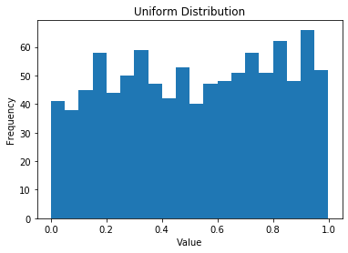

```python
gaussian_numbers = np.random.rand(1000)
plt.hist(gaussian_numbers, bins=20)

plt.title("Uniform Distribution")
plt.xlabel("Value")
plt.ylabel("Frequency")
plt.show()
```

위 그래프를 통해 알 수 있듯이 생성된 난수들은 0과 1사이에 골고루 퍼져 있도록 생성되었음을 대략 확인할 수 있다.

#### 표준정규분포(Standard Normal Distribution)

먼저 `np.random.randn()` 함수가 생성한 난수들이 표준정규분포를 따른다는 사실을 히스토그램을 이용하여 확인하자. 아래 코드는 1,000개의 난수를 표준정규분포를 사용하여 생성한 다음에 히스토그램을 그린다.

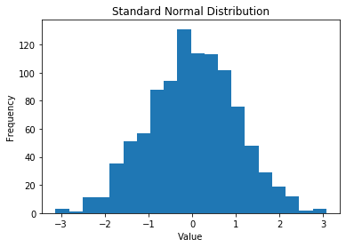

```python
gaussian_numbers = np.random.randn(1000)
plt.hist(gaussian_numbers, bins=20)

plt.title("Standard Normal Distribution")
plt.xlabel("Value")
plt.ylabel("Frequency")
plt.show()
```

# 인덱싱과 슬라이싱

기존의 시퀀스 자료형처럼 인덱싱과 슬라이싱을 이용하여 어레이 항목들을 확인할 수 있다.

## 1차원 어레이의 인덱싱과 슬라이싱

1차원 어레이의 경우 리스트의 인덱싱, 슬라이싱과 동일하게 처리한다. 다만, 슬라이싱의 경우 리턴값 또한 1차원 어레이이다.

```python
import numpy as np
```

### 인덱싱

인덱싱은 숫자 0부터 인덱스가 시작하며, `-1`은 마지막 항목을 의미한다.

```python
a = np.arange(10)
a
```

```
array([0, 1, 2, 3, 4, 5, 6, 7, 8, 9])
```

```python
a[0], a[2], a[-1]
```

```
(0, 2, 9)
```

### 슬라이싱

두 개의 콜론(':')을 사용하여 슬라이싱 구간의 처음과 끝, 그리고 스텝 옵션을 지정할 수 있다. -1은 역순으로 나열하는 것을 의미한다.

```python
a[::-1]
```

```
array([9, 8, 7, 6, 5, 4, 3, 2, 1, 0])
```

```python
a[2:9:3] # [start:end:step]
```

```
array([2, 5, 8])
```

```python
a[:4]
```

```
array([0, 1, 2, 3])
```

```python
a[1:3]
```

```
array([1, 2])
```

```python
a[::2]
```

```
array([0, 2, 4, 6, 8])
```

```python
a[3:]
```

```
array([3, 4, 5, 6, 7, 8, 9])
```

## 고차원 어레이의 인덱싱과 슬라이싱

### 인덱싱

어레이이 인덱싱은 좌표 개념을 활용한다.

```python
b = np.array([[0, 1, 2], [3, 4, 5]])
b
```

```
array([[0, 1, 2],
       [3, 4, 5]])
```

```python
b[0, 0]
```

```
0
```

```python
b[1,2]
```

```
5
```

따라서, 다차원 어레이에서 사용되는 인덱싱은 인덱스 숫자들의 튜플을 사용한다. 사용된 튜플의 길이만큼 인덱싱의 대상이 되는 항목들의 차원이 증가한다.

보다 다양한 예제들을 이용하여 인덱싱을 연습해보자.

```python
d = np.diag(np.arange(3))
d
```

```
array([[0, 0, 0],
       [0, 1, 0],
       [0, 0, 2]])
```

`1`의 위치는 2행 2열이므로 인덱싱을 `(1, 1)`을 이용한다.

```python
d[1, 1]
```

```
1
```

어레이의 특정 항목의 값을 변경할 수 있다. 즉, 어레이는 가변(mutable) 자료형이다. 예를 들어, 3행 2열 항목값인 0을 10으로 변경하고자 하면 다음과 같이 인덱싱을 이용하면 된다.

```python
d[2, 1] = 10
d
```

```
array([[ 0,  0,  0],
       [ 0,  1,  0],
       [ 0, 10,  2]])
```

`d[2]`는 무엇을 의미할까? `d`를 리스트라 생각하면 이해가 될 것이다. 즉, 3번째 항목인 `[0, 10, 2]`를 가리킨다.

```python
d[2]
```

```
array([ 0, 10,  2])
```

### 슬라이싱

다차원 어레이의 슬라이싱은 좀 더 집중을 요구한다. 복잡하거나 어렵지는 않지만 항상 집중해야 한다.

먼저, 다음과 같은 모양의 2차원 어레이를 생성해보자. 단, 수동으로 항목들을 입력하면 안된다.

| 0 | 1 | 2 | 3 | 4 | 5 |
| --- | --- | --- | --- | --- | --- |
| 10 | 11 | 12 | 13 | 14 | 15 |
| 20 | 21 | 22 | 23 | 24 | 25 |
| 30 | 31 | 32 | 33 | 34 | 35 |
| 40 | 41 | 42 | 43 | 44 | 45 |
| 50 | 51 | 52 | 53 | 54 | 55 |

여러 가지 방법이 있을 수 있으나 shape을 변경하는 방법을 활용하는 것이 가장 기초적이다. 먼저, `np.arange` 함수를 이용하여 길이가 36인 어레이를 생성한 다음에 shape 값을 변경하여 2차원 어레이를 생성한다.

```python
a = np.arange(36)
a.shape = (6,6)
a
```

```
array([[ 0,  1,  2,  3,  4,  5],
       [ 6,  7,  8,  9, 10, 11],
       [12, 13, 14, 15, 16, 17],
       [18, 19, 20, 21, 22, 23],
       [24, 25, 26, 27, 28, 29],
       [30, 31, 32, 33, 34, 35]])
```

`shape` 변경하는 여러 가지 방법이 있다.

- `shape` 속성을 위와 같이 변경하기.
- `reshape` 메소드 이용하기

```python
a = np.arange(36).reshape((6,6))
a
```

```
array([[ 0,  1,  2,  3,  4,  5],
       [ 6,  7,  8,  9, 10, 11],
       [12, 13, 14, 15, 16, 17],
       [18, 19, 20, 21, 22, 23],
       [24, 25, 26, 27, 28, 29],
       [30, 31, 32, 33, 34, 35]])
```

이제 각 행별로 4의 배수를 더하면 원하는 어레이가 얻어지는 성질을 이용한다. 어레이와 숫자의 연산은 각 항목별로 실행된다는 점을 이용한다.

```python
a = np.arange(36).reshape((6,6))

for i in range(len(a)):
    a[i] = a[i] + 4*i

a
```

```
array([[ 0,  1,  2,  3,  4,  5],
       [10, 11, 12, 13, 14, 15],
       [20, 21, 22, 23, 24, 25],
       [30, 31, 32, 33, 34, 35],
       [40, 41, 42, 43, 44, 45],
       [50, 51, 52, 53, 54, 55]])
```

- 위 코드를 보다 친숙한 방식으로 구현한다면 다음과 같다.

```python
a = np.arange(36).reshape((6,6))

for i in range(len(a)):
        for j in range(6):
            a[i, j] = a[i, j] + 4*i

a
```

```
array([[ 0,  1,  2,  3,  4,  5],
       [10, 11, 12, 13, 14, 15],
       [20, 21, 22, 23, 24, 25],
       [30, 31, 32, 33, 34, 35],
       [40, 41, 42, 43, 44, 45],
       [50, 51, 52, 53, 54, 55]])
```

- 보다 간단하지만 **브로드캐스팅(broadcasting)**이라는 고급 기술을 이용하는 방식은 다음과 같다.
- 브로드캐스팅: 연산하려는 두 어레이의 모양(shape)을 맞추려는 시도 정도로 이해하면 됨.

```python
a = np.arange(6) + np.arange(0, 51, 10)[:, np.newaxis]
a
```

```
array([[ 0,  1,  2,  3,  4,  5],
       [10, 11, 12, 13, 14, 15],
       [20, 21, 22, 23, 24, 25],
       [30, 31, 32, 33, 34, 35],
       [40, 41, 42, 43, 44, 45],
       [50, 51, 52, 53, 54, 55]])
```

**`a[0, 3:5]`** 확인하기

먼저 `a[0]`를 확인한다.

```python
a[0]
```

```
array([0, 1, 2, 3, 4, 5])
```

따라서 `a[0, 3:5]` 결과는 아래와 같다.

```python
a[0, 3:5]
```

```
array([3, 4])
```

**`a[4:, 4:]`** 확인하기 1차원 값과 2차원 값을 함께 생각해야 한다.

- 첫번 째 `'4:'`는 4번 인덱스 행부터 마지막 행까지 전체를 의미한다.
- 두번 째 `'4:'`는 앞서 선택한 4번 인덱스 행부터 마지막 행 각각에서 4번 인덱스 열부터 전체를 나타낸다.

```python
a[4:, 4:]
```

```
array([[44, 45],
       [54, 55]])
```

위와 비슷한 방식으로 해석하면 아래 코드도 이해할 수 있다.

- `':'` 은 모든 행을 대상으로 삼는 것이고
- `'2'` 는 각 행에서 2번 인덱스 값을 선택한다는 의미이다.

따라서 아래 값이 나온다.

```python
a[:, 2]
```

```
array([ 2, 12, 22, 32, 42, 52])
```

이제 아래 코드를 이해할 수 있어야 한다.

```python
a[2::2, ::2]
```

```
array([[20, 22, 24],
       [40, 42, 44]])
```